# Time series *beer* with Holt-Winters algorithms

Rozenn Dahyot - https://www.scss.tcd.ie/Rozenn.Dahyot/

2019

The time series *beer* is in the fma package:

```r
# make sure to type in Rstudio console: install.packages("fma")
require("fma")
beer
```

```
##      Jan Feb Mar Apr May Jun Jul Aug Sep Oct Nov Dec
## 1991 164 148 152 144 155 125 153 146 138 190 192 192
## 1992 147 133 163 150 129 131 145 137 138 168 176 188
## 1993 139 143 150 154 137 129 128 140 143 151 177 184
## 1994 151 134 164 126 131 125 127 143 143 160 190 182
## 1995 138 136 152 127 151 130 119 153
```

Description of beer: Monthly Australian beer production: Jan 1991 to Aug 1995.

## Visualisation of time series

### Time plot

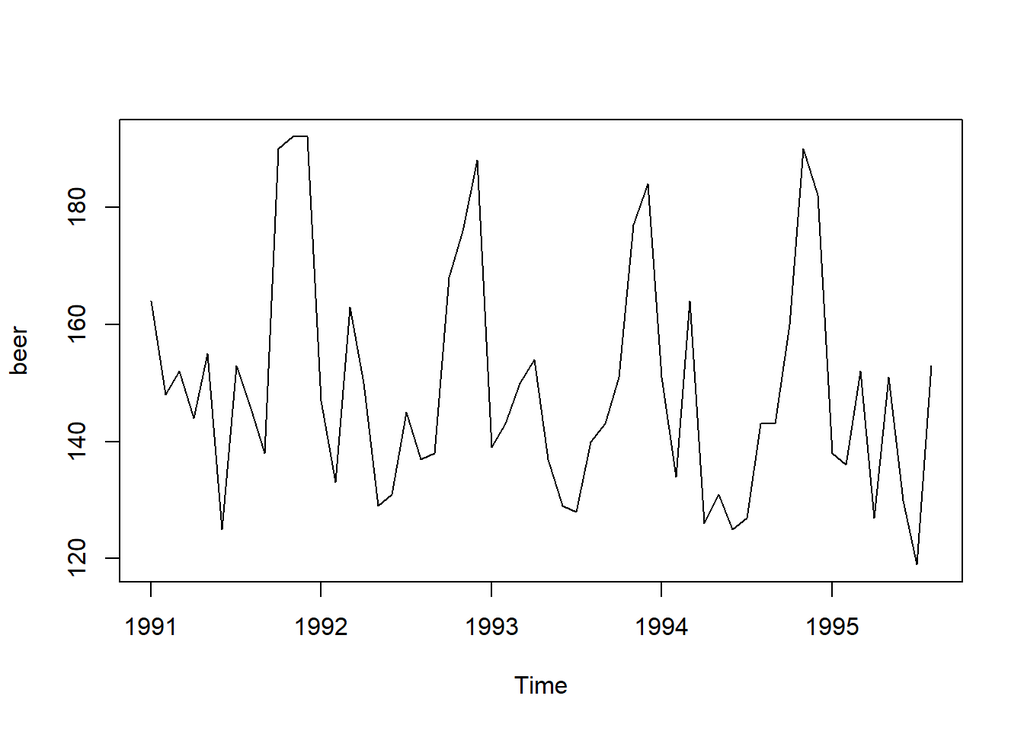

```r
plot(beer)
```

### Time plot with ACF and PACF

The ACF and PACF can be displayed with the time plot:

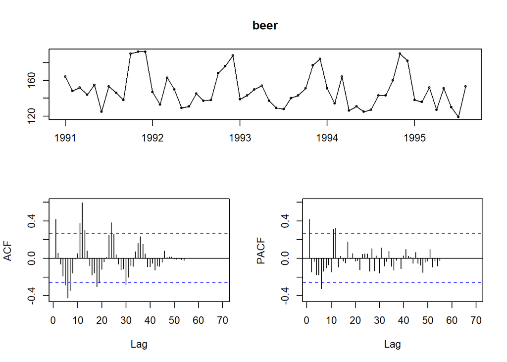

```r
tsdisplay(beer,lag.max=70)
```

Other packages exist for visualisation. For instance you may prefer using packages *ggplot2*

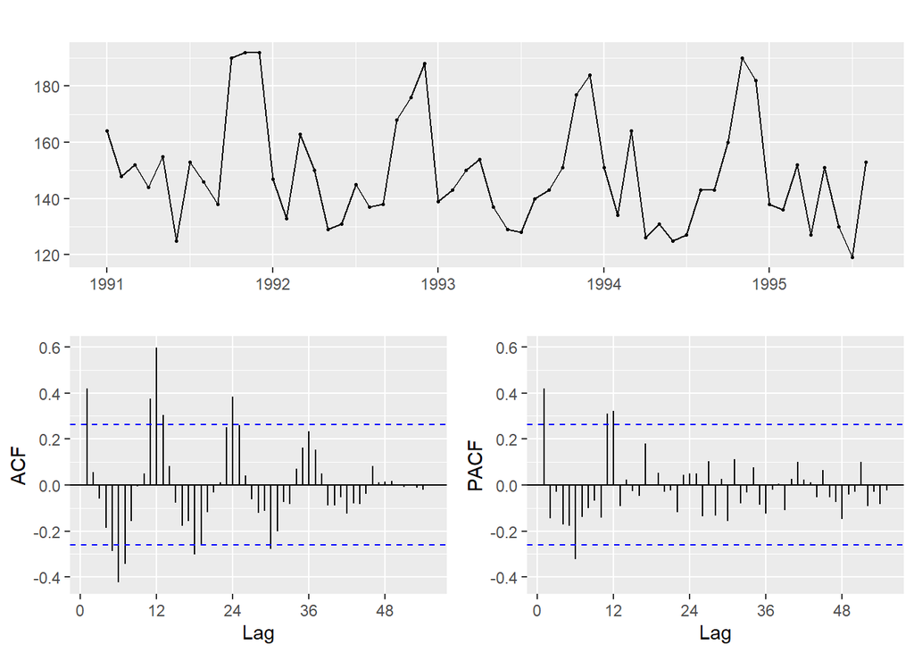

```r
# make sure to type in Rstudio console: install.packages("ggplot2")
require(ggplot2)
ggtsdisplay(beer,lag.max = 70)
```

The timeplot shows seasonality, no real trend and some noise.  
For the time series *beer*, the ACF displays maxima at lags 12, 24, 36 (…) characteristic of seasonality with a period of 12 months (as it is monthly data).

**Exercise:** Show how to use the R functions *acf()* and *pacf()* for the time series *beer*. Explain the the differences with *tsdisplay()* (hint: look at the x-axis)

**Exercise:** Comment on the information provided by the PACF for the time series *beer*.

### seasonplot()

The season plot confirms there is no trend.

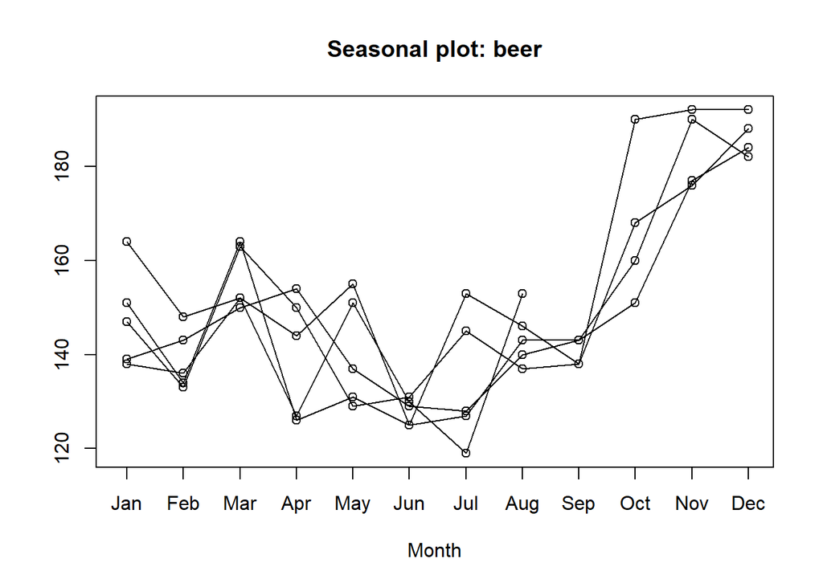

```r
seasonplot(beer)
```

### Function *ts()*

Note that *beer* time series is stored in *fma* package explicitly with this information of periodicity 12. For the *mink* time series which has no frequency information stored, then you will need to use the function *ts* to indicate a period (if you see one!) for this time series e.g.:

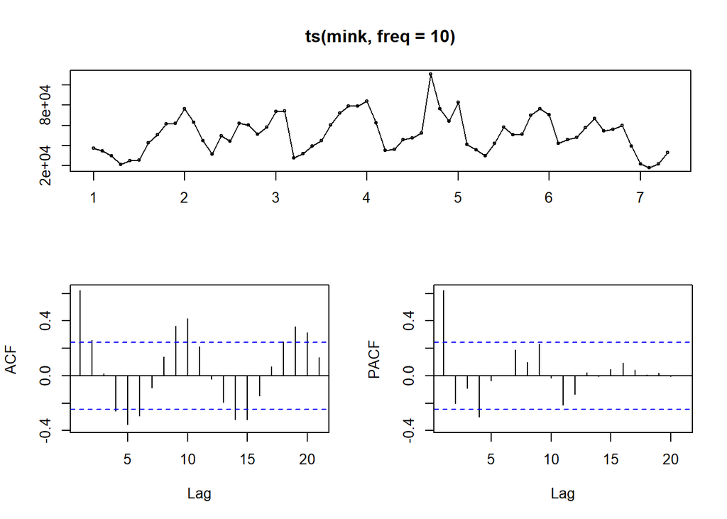

```r
tsdisplay(ts(mink,freq=10))
```

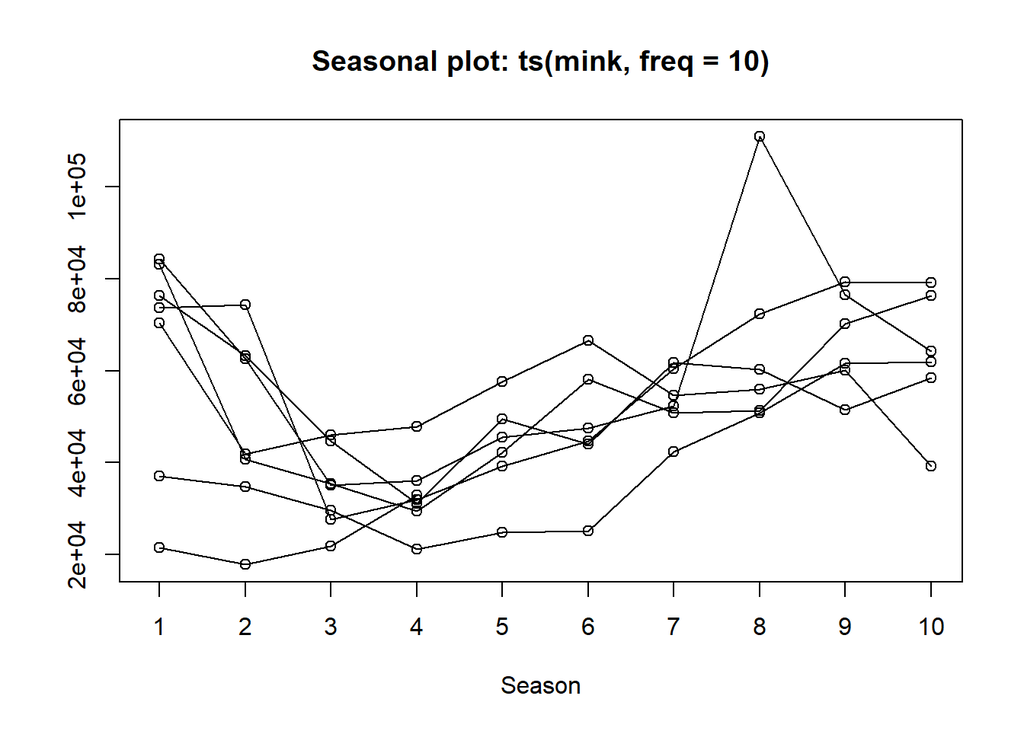

```r
seasonplot(ts(mink,freq=10))
```

### Function *decompose()*

Note that the function *decompose* can be visually misleading:

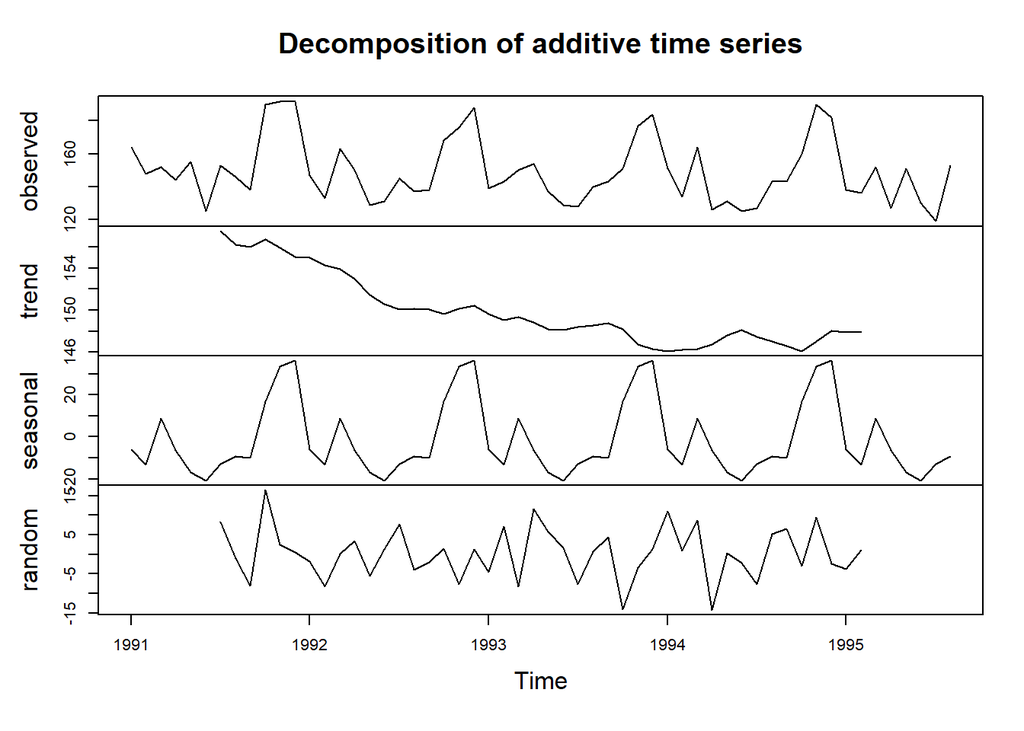

```r
plot(decompose(beer))
```

It may look like you have trend!

**Exercise:** Read chapter 6 at  
https://otexts.com/fpp2/decomposition.html . What other R function can be used for decomposing time series ?

## Fitting Holt Winters algorithms

Only seasonal algorithms are appropriate for fitting the time series *beer*.

```r
HoltWinters(beer, seasonal="additive")$SSE
```

```
## [1] 4164.097
```

```r
HoltWinters(beer, seasonal="multiplicative")$SSE
```

```
## [1] 3851.269
```

Using SSE (Sum of Square Errors), the seasonal Holt Winters algorithm (SHWx) algorithm fits best the time series *beer* (lowest SSE).

**Exercise:** How to compute MAPE with R ? Would the same Holt-Winters algorithm selected with MAPE ?

## Computing forecasts

```r
HoltWinters(beer, seasonal="multiplicative")
```

```
## Holt-Winters exponential smoothing with trend and multiplicative seasonal component.
##
## Call:
## HoltWinters(x = beer, seasonal = "multiplicative")
##
## Smoothing parameters:
##  alpha: 0.02225387
##  beta : 0.6221156
##  gamma: 0.6728938
##
## Coefficients:
##            [,1]
## a   146.0859896
## b     0.2459431
## s1    0.9794233
## s2    1.0969580
## s3    1.2794748
## s4    1.2586982
## s5    0.9702512
## s6    0.9337021
## s7    1.0637137
## s8    0.8905903
## s9    0.9948355
## s10   0.8842001
## s11   0.8398353
## s12   1.0240620
```

```r
predict(HoltWinters(beer, seasonal="multiplicative"))
```

```
##           Sep
## 1995 143.3209
```

Using the formula
$$F_{n+k} = (L_n+k \times b_n)\times S_{n+k-s}$$
with $k=1$, $s=12$ (frequency for beer data), and with the notation used in the lecturenotes https://www.scss.tcd.ie/Rozenn.Dahyot/ST3010/RzDTimeSeriesForecasting.pdf (chapter 8), the prediction can be computed (instead of using the R command *predict()*) as follow

```r
k=1  # prediction computed 1 month ahead
s=12 # frequency 12 month
Ln=HoltWinters(beer, seasonal="multiplicative")$coefficients[1]
bn=HoltWinters(beer, seasonal="multiplicative")$coefficients[2]
snk= HoltWinters(beer, seasonal="multiplicative")$coefficients[3]
(Ln+k*bn)*snk
```

```
##        a
## 143.3209
```

Likewise prediction can be computed for $k=5$ months ahead from the last observation of the time series *beer* :

```r
k=5  # prediction computed 1 month ahead
s=12 # frequency 12 month
Ln=HoltWinters(beer, seasonal="multiplicative")$coefficients[1]
bn=HoltWinters(beer, seasonal="multiplicative")$coefficients[2]
snk= HoltWinters(beer, seasonal="multiplicative")$coefficients[7]
(Ln+k*bn)*snk
```

```
##        a
## 142.9332
```

```r
predict(HoltWinters(beer, seasonal="multiplicative"),n.ahead=5)[5]
```

```
## [1] 142.9332
```

### Using *forecast()*

```r
forecast(HoltWinters(beer, seasonal="multiplicative"),h=1)
```

```
##          Point Forecast    Lo 80    Hi 80    Lo 95    Hi 95
## Sep 1995       143.3209 135.1236 151.5182 130.7841 155.8577
```

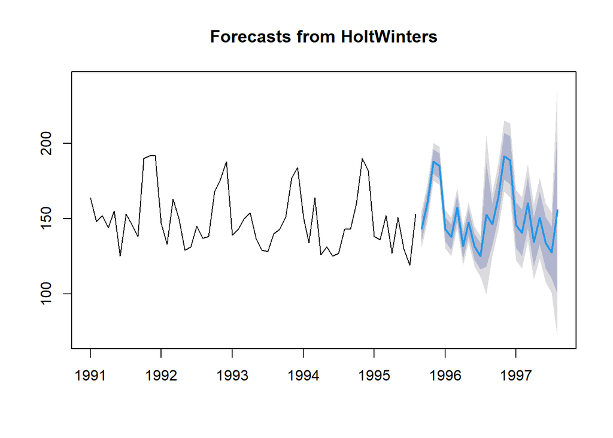

```r
plot(forecast(HoltWinters(beer, seasonal="multiplicative")))
```

**Exercise:** Explain how the R function *forecast()* relates to *predict()*. Explain how prediction intervals are computed.

## Other questions

**Exercise:** What Warnings should one be aware of about using the computed forecasts with Holt Winters algorithms ? What hypotheses are made when computing the prediction intervals associated with the forecasts ?

**Exercise:** Read *The Holt-Winters Approach to Exponential Smoothing: 50 Years Old and Going Strong* by Paul Goodwin in FORESIGHT Fall 2010 ( http://citeseerx.ist.psu.edu/viewdoc/download?doi=10.1.1.401.2999&rep=rep1&type=pdf ). Explain how Holt-Winters algorithms have been extended ?